# Solution steps

```python
# improt dependencies
import pandas as pd
import numpy as np
from sklearn import linear_model
from sklearn.model_selection import train_test_split
from sklearn.metrics import r2_score
from sklearn.linear_model import *
from sklearn.preprocessing import PolynomialFeatures
from sklearn.pipeline import make_pipeline

import seaborn as sns
import matplotlib.pyplot as plt
%matplotlib inline
```

```python
# read data
df_main = pd.read_csv('./data/data.csv')
```

```python
# let's peek into the dataset
df_main.head()
```

|  | Tm | Pr | Th | Sv | Idx |
| --- | --- | --- | --- | --- | --- |
| 0 | -20 | 500 | 0.027368 | 350.861031 | 54.903239 |
| 1 | -20 | 500 | 0.027023 | 343.897695 | 52.155342 |
| 2 | -20 | 500 | 0.026678 | 336.475830 | 49.533201 |
| 3 | -20 | 500 | 0.026333 | 330.290415 | 47.025757 |
| 4 | -20 | 500 | 0.025988 | 324.433876 | 44.623440 |

```python
# describe the dataset
df_main.describe()
```

|  | Tm | Pr | Th | Sv | Idx |
| --- | --- | --- | --- | --- | --- |
| count | 2376.000000 | 2376.000000 | 2376.000000 | 2376.000000 | 2376.000000 |
| mean | 30.000000 | 1750.000000 | 0.031347 | 370.428753 | 36.955041 |
| std | 34.163693 | 854.092316 | 0.004823 | 47.564937 | 6.562916 |
| min | -20.000000 | 500.000000 | 0.022739 | 280.730251 | 26.836172 |
| 25% | 0.000000 | 1000.000000 | 0.027244 | 330.670679 | 31.723869 |
| 50% | 30.000000 | 1750.000000 | 0.031238 | 365.567203 | 35.622198 |
| 75% | 60.000000 | 2500.000000 | 0.035286 | 405.090140 | 41.405485 |
| max | 80.000000 | 3000.000000 | 0.042237 | 528.087720 | 54.903239 |

```python
df_main.info()
```

```
<class 'pandas.core.frame.DataFrame'>
RangeIndex: 2376 entries, 0 to 2375
Data columns (total 5 columns):
Tm     2376 non-null int64
 Pr    2376 non-null int64
Th     2376 non-null float64
Sv     2376 non-null float64
Idx    2376 non-null float64
dtypes: float64(3), int64(2)
memory usage: 92.9 KB
```

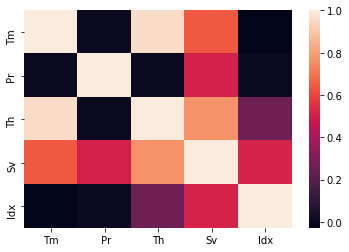

```python
# calculate the correlation matrix
corr = df_main.corr()

# plot the correlation heatmap
sns.heatmap(corr,
        xticklabels=corr.columns,
        yticklabels=corr.columns)
```

The above heatmap shows the correlation between all the features. Correlation of 'Sv' with 'Idx' is comparitively higher. And below the scatter plot shows that there is a linear relationship between those two variables. The same you will find in 'Th' and 'Idx'.

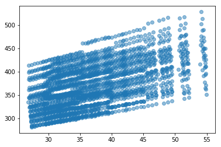

```python
plt.scatter(df_main['Idx'], df_main['Sv'], alpha=0.5)
```

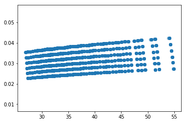

```python
plt.scatter(df_main['Idx'], df_main['Th'], alpha=0.5)
```

```python
columns_x = ['Th', 'Sv', 'Tm', ' Pr']
column_label = ['Idx']
```

```python
X = df_main[columns_x]
y = df_main[column_label]
```

Now, let's split the data into train and test.

```python
X_train, X_test, y_train, y_test = train_test_split(X, y, test_size=0.33, random_state=42)
```

```python
print(X_train.shape)
print(X_test.shape)
```

```
(1591, 4)
(785, 4)
```

### The first linear model we'll try is LinearRegression model

```python
reg = LinearRegression()
reg = reg.fit(X_train, y_train)
```

Our model is trained, now we'll calculate R2 score. Which is a statistical measure of how close the data is to the fitted regression line. Best possible score is 1.0 and it can be negative (because the model can be arbitrarily worse).

```python
y_pred = reg.predict(X_test)
r2_score(y_test, y_pred)
```

```
0.975110330464747
```

```python
# other way of calculating the R2 score
reg.score(X_test, y_test)
```

```
0.975110330464747
```

Below is the list of weights and bias of the trained linear regression model.

```python
print("weights: ",reg.coef_)
print("bias: ",reg.intercept_)
```

```
weights:  [[ 3.61334358e+03  5.55861130e-02 -5.43785108e-01 -1.60560837e-03]]
bias:  [-77.78381734]
```

Now I'll demonstrate how to use k-fold cross validation

```python
# split array in k(number of folds) sub arrays
X_folds = np.array_split(X_train, 3)
y_folds = np.array_split(y_train, 3)
scores = list()
models = list()
for k in range(3):
    reg = LinearRegression()

    # We use 'list' to copy, in order to 'pop' later on
    X_train_fold = list(X_folds)
    # pop out kth sub array for testing
    X_test_fold  = X_train_fold.pop(k)
    # concatenate remaining sub arrays for training
    X_train_fold = np.concatenate(X_train_fold)

    # same process for y
    y_train_fold = list(y_folds)
    y_test_fold  = y_train_fold.pop(k)
    y_train_fold = np.concatenate(y_train_fold)

    reg = reg.fit(X_train_fold, y_train_fold)
    scores.append(reg.score(X_test_fold, y_test_fold))
    models.append(reg)

print(scores)
```

```
[0.9783321790402408, 0.9732533362920268, 0.9757403443220285]
```

I have taken only one linear model as an example here, but you can try different models. And compare them.

### Polynomial model

In sklearn, there is a module named make_pipeline in sklearn. So, in order to use the polynomial or non-linear model, what we have to do is, we make a pipeline with a linear model(LinearRegression, in out case) to PolynomialFeatures (which is also a class that takes 'degree' of polinomial in its constructor).

```python
# polynomial model
for count, degree in enumerate([2, 3, 4, 5, 6]):
    print("Degree ",degree)
    model = make_pipeline(PolynomialFeatures(degree), LinearRegression())
    model.fit(X_train, y_train)
    y_pred = model.predict(X_test)
    print("R2 score: ",r2_score(y_test, y_pred))
    print("coefficiets: ",model.steps[1][1].coef_)
    print("bias: ",model.steps[1][1].intercept_)
    print("---------------------------------")
    print()
```

```
Degree  2
R2 score:  0.9977539086415744
coefficiets:  [[ 0.00000000e+00 -4.85960182e+03 -7.27625346e-02  1.25260432e+00
   2.97853694e-03  1.80569531e+05  4.34191649e-01 -6.76552207e+01
  -5.01666125e-02  1.17246625e-04 -2.99243256e-04 -6.06409432e-06
   5.57667785e-03  1.23346472e-05  6.28142516e-08]]
bias:  [42.67088036]
---------------------------------

Degree  3
R2 score:  0.9982094232909468
coefficiets:  [[-1.50710394e-02 -7.32192228e+03 -5.73182027e-01  4.84214298e-01
   2.12880412e-02 -6.93550028e+01  2.37257849e+01  8.21910081e+01
  -8.74639918e-01  9.60799916e-04 -5.41180844e-03 -6.62240158e-05
  -1.05196680e-02  1.44848568e-04  1.56866759e-06 -6.49480887e-01
   1.11474718e+03 -3.46959329e+03 -2.74389098e+01 -1.44910931e-01
  -3.37019067e-03  8.54180535e-03  8.31446819e-01 -1.20050989e-03
  -1.77467221e-04  3.38836003e-06  9.32266355e-06 -3.04314938e-07
  -1.22471299e-05 -4.29463626e-07  1.19430297e-08 -5.34586890e-05
   3.89265495e-07  1.03782440e-08 -1.65528036e-10]]
bias:  [142.85265425]
---------------------------------

Degree  4
R2 score:  0.9983342869614551
coefficiets:  [[-9.71815096e-06  1.33459938e-01  2.32389922e-01 -9.75723171e-02
   7.76462163e-03 -3.99813510e-04  1.48669846e-03  9.02522143e-03
   1.36410976e-01 -1.52540211e-03 -1.74510805e-03  2.82645382e-05
   1.10011515e-02  2.09326221e-04 -5.13146091e-06 -5.13301845e-06
  -1.41195096e-04 -8.37917777e-04  1.07872861e-02  4.02834115e-02
   2.88829306e-01 -2.27528511e-02 -8.56879148e-01 -7.86460587e-03
   2.18039726e-03  5.93459745e-07 -6.76265548e-06  1.74929758e-06
  -4.37680478e-05  5.51864658e-07 -2.19814315e-07  1.15501756e-04
   1.62427782e-06 -7.64646246e-08  4.96604191e-09 -4.22697310e-08
  -1.67476853e-04 -9.82976872e-05  2.59347501e-04 -3.92913993e-01
  -3.42668592e-01  1.22648380e+00 -7.04965421e-02 -1.07054859e+00
  -1.26174667e-01  1.15709001e-04 -1.30106662e-03 -1.59921419e-04
   4.41826693e-03  3.87139915e-05  2.00948969e-05 -3.23536318e-03
   5.25078607e-05  1.57483958e-05 -4.22188599e-07 -7.16240811e-09
   5.54472781e-08  4.73381900e-09 -5.63812303e-08  4.66708096e-09
```

[output cut: 85 more lines]

```
  -1.70429711e-08 -2.05947214e-09  7.45919725e-10  1.43917752e-09
   3.97731557e-08 -6.32437614e-09 -8.69611536e-10 -9.98276467e-08
  -7.84631345e-09  3.40494794e-09  1.51382108e-10 -1.22001318e-08
  -3.72651512e-09  6.15201865e-10 -4.93500996e-10 -1.10252865e-11
   2.61280917e-10  1.15373127e-07 -2.42634053e-09  2.98301616e-11
   2.18864276e-11  3.35142478e-13 -1.09754959e-13  1.30955295e-12
   1.21354218e-13 -3.90741185e-12 -6.64809103e-13 -1.87352362e-14
  -1.36334873e-12  2.47222189e-12  1.39931586e-13  5.48476653e-17
   4.31792029e-11  1.07665883e-13 -7.09942599e-13 -1.47293858e-14
   2.67723249e-16 -1.15443161e-10 -8.85040474e-12  2.70372851e-13
   7.20335604e-14  8.62697602e-16 -3.37383714e-17  2.16715558e-10
  -5.72731227e-12  4.47518748e-13 -1.49411986e-14 -2.52453402e-15
  -2.63860716e-17  1.45749224e-18]]
bias:  [10.19603115]
---------------------------------
```